# Eating disorders Montecatini

PRL parameters for patients/controls classification

Corrado Caudek

First version 2022-06-08. Last modified 2022-06-09.

## Purpose

A script to classify patients/controls by using the hDDM parameters. Only the four alpha parameters are used, so as to have the same number of ‘features’ as in the task-switching experiment.

Notes:

When the individual parameters of hDDMrl are computed without the knowledge of the group (NO split_by = is_patient), there is no shrinkage that makes more similar to each other the participants’ individual parameters of each group. In these conditions, by using the parameters computed in the food condition, no ability for clinical classification emerges: AUC = 0.55.

To generate the html, run: `rmarkdown::render("scripts/R/scripts_prl/02_hddmrl_params_analyses/classification_tutorial.R")`

## Prelims

```r
suppressPackageStartupMessages({
  library("here")
  library("tidyverse")
  library("tidyr")
  library("cmdstanr")
  library("lemon")
  library("bayesplot")
  theme_set(bayesplot::theme_default(base_family = "sans"))
  library("pROC")
  library("tidymodels")
  library("readr")
  library("vip")
})

# Increase max print
options(max.print = .Machine$integer.max)

cores <- parallel::detectCores()
cores
```

```
## [1] 8
```

```r
source(here("scripts", "functions", "funs_param_analyses.R"))
source(here("scripts", "functions", "funs_param_classification_analyses.R"))
```

## Get parameter estimates

```r
prl_params <- rio::import(
  here::here(
    "data", "processed", "prl", "output_hddm", "hddmrl_output_clean2.txt"
  )
)

prl_params <- prl_params %>%
  dplyr::select(
    param_prl, diag_cat, stim, subj_idx, value_prl
  )
prl_params %>% head()
```

```
##   param_prl diag_cat stim subj_idx value_prl
## 1         a       AN food        1  1.266322
## 2         a       AN food        6  1.351356
## 3         a       AN food        7  1.541692
## 4         a       AN food        9  1.144942
## 5         a       AN food       10  1.635574
## 6         a       AN food       11  1.522234
```

```r
prl_params <- prl_params %>%
  mutate_if(is.character, as.factor)

two_groups <- prl_params[prl_params$diag_cat %in% c("AN", "HC"), ]
two_groups$diag_cat <- factor(two_groups$diag_cat)

dat <- two_groups %>%
  pivot_wider(
    names_from = c(param_prl),
    values_from = value_prl
  )
# dat %>% head()

dat1 <- dat %>%
  pivot_wider(
    names_from = stim,
    values_from = c(a, v, t, alpha, pos_alpha)
  )


dat_hc <- dat1 %>%
  dplyr::filter(diag_cat == "HC")
dat_hc$is_patient <- 0

dat_an <- dat1 %>%
  dplyr::filter(diag_cat == "AN")
dat_an$is_patient <- 1
# length(unique(dat_an$subj_idx))

# Select random 31 subjects from the HC group
subj_idx_hc <- unique(dat_hc$subj_idx)
chosen_subjects <- sample(subj_idx_hc, 31)
dat31_hc <- dat_hc[dat_hc$subj_idx %in% chosen_subjects, ]

# Select random 31 subjects from the AN group
subj_idx_an <- unique(dat_an$subj_idx)
chosen_subjects <- sample(subj_idx_an, 31)
dat31_an <- dat_an[dat_an$subj_idx %in% chosen_subjects, ]

two_groups31_df <- rbind(dat31_an, dat31_hc)


dat <- two_groups31_df %>%
  dplyr::select(
    is_patient,
    alpha_food, alpha_neutral, pos_alpha_food, pos_alpha_neutral
    #, a_food, a_neutral, v_food, v_neutral, t_food, t_neutral
  )

dat$is_patient <- ifelse(
  dat$is_patient == 1, "patient", "control"
)
```

## Follow the tutorial

The tutorial is provided in the following blog post: [Tidymodels: tidy machine learning in R](https://www.rebeccabarter.com/blog/2020-03-25_machine_learning/)

First, let’s split our dataset into training and testing data. The training data will be used to fit our model and tune its parameters, where the testing data will be used to evaluate our final model’s performance. This split can be done automatically using the inital_split() function (from rsample) which creates a special “split” object.

```r
# split the data into trainng (60%) and testing (40%)
diabetes_split <- initial_split(dat, prop = 0.6)
diabetes_split
```

```
## <Analysis/Assess/Total>
## <37/25/62>
```

The training and testing sets can be extracted from the “split” object using the training() and testing() functions. Although, we won’t actually use these objects in the pipeline (we will be using the diabetes_split object itself).

```r
# extract training and testing sets
diabetes_train <- training(diabetes_split)
diabetes_test <- testing(diabetes_split)
```

At some point we’re going to want to do some parameter tuning, and to do that we’re going to want to use cross-validation. So we can create a cross-validated version of the training set in preparation for that moment using vfold_cv().

```r
# create CV object from training data
diabetes_cv <- vfold_cv(diabetes_train)
```

## Define a recipe

Recipes allow you to specify the role of each variable as an outcome or predictor variable (using a “formula”), and any pre-processing steps you want to conduct.

```r
# define the recipe
diabetes_recipe <-
# which consists of the formula (outcome ~ predictors)
recipe(
  is_patient ~ .,
  data = dat
  ) %>%
# and some pre-processing steps
  step_normalize(all_numeric()) %>%
  step_knnimpute(all_predictors())

diabetes_recipe
```

```
## Recipe
##
## Inputs:
##
##       role #variables
##    outcome          1
##  predictor          4
##
## Operations:
##
## Centering and scaling for all_numeric()
## K-nearest neighbor imputation for all_predictors()
```

If you want to extract the pre-processed dataset itself, you can first prep() the recipe for a specific dataset and juice() the prepped recipe to extract the pre-processed data. It turns out that extracting the pre-processed data isn’t actually necessary for the pipeline, since this will be done under the hood when the model is fit, but sometimes it’s useful anyway.

```r
diabetes_train_preprocessed <- diabetes_recipe %>%
  # apply the recipe to the training data
  prep(diabetes_train) %>%
  # extract the pre-processed training dataset
  juice()
diabetes_train_preprocessed
```

```
## # A tibble: 37 × 5
##    alpha_food alpha_neutral pos_alpha_food pos_alpha_neutral is_patient
##         <dbl>         <dbl>          <dbl>             <dbl> <fct>
##  1     -0.211        -1.01           0.999           -2.04   control
##  2      1.09          1.13          -0.401           -1.27   patient
##  3      1.07          0.389         -0.446            0.0435 control
##  4     -0.827        -1.99           0.305           -0.954  control
##  5      0.860         0.792          1.37            -0.972  patient
##  6      0.231        -0.289          0.882           -0.538  control
##  7     -0.397        -1.25          -0.290           -0.613  patient
##  8      0.342         1.36          -0.328            0.454  patient
##  9      1.09         -0.520          0.312            0.245  patient
## 10     -0.883        -0.193         -0.296            1.42   patient
## # … with 27 more rows
```

## Specify the model

The next thing we want to specify is our model (using the parsnip package). Parsnip offers a unified interface for the massive variety of models that exist in R.

We want to fit a random forest model as implemented by the ranger package for the purpose of classification and we want to tune the mtry parameter (the number of randomly selected variables to be considered at each split in the trees).

```r
rf_model <-
  # specify that the model is a random forest
  rand_forest() %>%
  # specify that the `mtry` parameter needs to be tuned
  set_args(mtry = tune(), trees = tune()) %>%
  # select the engine/package that underlies the model
  set_engine("ranger", importance = "impurity") %>%
  # choose either the continuous regression or binary classification mode
  set_mode("classification")
```

Note that this code doesn’t actually fit the model. Like the recipe, it just outlines a description of the model. Moreover, setting a parameter to tune() means that it will be tuned later in the tune stage of the pipeline (i.e. the value of the parameter that yields the best performance will be chosen). The following code instead specifies a logistic regression model from the glm package.

```r
lr_model <-
  # specify that the model is a random forest
  logistic_reg() %>%
  # select the engine/package that underlies the model
  set_engine("glm") %>%
  # choose either the continuous regression or binary classification mode
  set_mode("classification")
```

## Put it all together in a workflow

We’re now ready to put the model and recipes together into a workflow. You initiate a workflow using workflow() (from the workflows package) and then you can add a recipe and add a model to it.

```r
# set the workflow
rf_workflow <- workflow() %>%
  # add the recipe
  add_recipe(diabetes_recipe) %>%
  # add the model
  add_model(rf_model)
```

Since we had a parameter that we designated to be tuned (mtry), we need to tune it (i.e. choose the value that leads to the best performance) before fitting our model. If you don’t have any parameters to tune, you can skip this step.

Note that we will do our tuning using the cross-validation object (diabetes_cv). To do this, we specify the range of mtry values we want to try, and then we add a tuning layer to our workflow using tune_grid() (from the tune package). Note that we focus on two metrics: accuracy and roc_auc (from the yardstick package).

```r
# specify which values eant to try
rf_grid <- expand.grid(mtry = c(2, 3, 4), trees = c(100, 500))
# extract results
rf_tune_results <- rf_workflow %>%
  tune_grid(resamples = diabetes_cv, #CV object
            grid = rf_grid, # grid of values to try
            metrics = metric_set(accuracy, roc_auc) # metrics we care about
  )
```

```
## ! Fold08: internal: No control observations were detected in `truth` with control level 'patient'.
```

```
## ! Fold09: internal: No event observations were detected in `truth` with event level 'control'.
```

```
## ! Fold10: internal: No control observations were detected in `truth` with control level 'patient'.
```

It’s always a good idea to explore the results of the cross-validation. collect_metrics() is a really handy function that can be used in a variety of circumstances to extract any metrics that have been calculated within the object it’s being used on. In this case, the metrics come from the cross-validation performance across the different values of the parameters.

```r
# print results
rf_tune_results %>%
  collect_metrics()
```

```
## # A tibble: 12 × 8
##     mtry trees .metric  .estimator  mean     n std_err .config
##    <dbl> <dbl> <chr>    <chr>      <dbl> <int>   <dbl> <chr>
##  1     2   100 accuracy binary     0.558    10  0.0513 Preprocessor1_Model1
##  2     2   100 roc_auc  binary     0.738     7  0.145  Preprocessor1_Model1
##  3     3   100 accuracy binary     0.583    10  0.0541 Preprocessor1_Model2
##  4     3   100 roc_auc  binary     0.619     7  0.138  Preprocessor1_Model2
##  5     4   100 accuracy binary     0.6      10  0.0509 Preprocessor1_Model3
##  6     4   100 roc_auc  binary     0.702     7  0.158  Preprocessor1_Model3
##  7     2   500 accuracy binary     0.592    10  0.0589 Preprocessor1_Model4
##  8     2   500 roc_auc  binary     0.738     7  0.134  Preprocessor1_Model4
##  9     3   500 accuracy binary     0.617    10  0.0468 Preprocessor1_Model5
## 10     3   500 roc_auc  binary     0.738     7  0.145  Preprocessor1_Model5
## 11     4   500 accuracy binary     0.592    10  0.0589 Preprocessor1_Model6
## 12     4   500 roc_auc  binary     0.702     7  0.138  Preprocessor1_Model6
```

We want to add a layer to our workflow that corresponds to the tuned parameter, i.e. sets mtry to be the value that yielded the best results. If you didn’t tune any parameters, you can skip this step.

We can extract the best value for the accuracy metric by applying the select_best() function to the tune object.

```r
param_final <- rf_tune_results %>%
  select_best(metric = "accuracy")
param_final
```

```
## # A tibble: 1 × 3
##    mtry trees .config
##   <dbl> <dbl> <chr>
## 1     3   500 Preprocessor1_Model5
```

Then we can add this parameter to the workflow using the finalize_workflow() function.

```r
rf_workflow <- rf_workflow %>%
  finalize_workflow(param_final)
```

## Evaluate the model on the test set

Now we’ve defined our recipe, our model, and tuned the model’s parameters, we’re ready to actually fit the final model. Since all of this information is contained within the workflow object, we will apply the last_fit() function to our workflow and our train/test split object. This will automatically train the model specified by the workflow using the training data, and produce evaluations based on the test set.

```r
rf_fit <- rf_workflow %>%
  # fit on the training set and evaluate on test set
  last_fit(diabetes_split)
```

Note that the fit object that is created is a data-frame-like object; specifically, it is a tibble with list columns.

```r
rf_fit
```

```
## # Resampling results
## # Manual resampling
## # A tibble: 1 × 6
##   splits          id               .metrics         .notes           .predictions .workflow
##   <list>          <chr>            <list>           <list>           <list>       <list>
## 1 <split [37/25]> train/test split <tibble [2 × 4]> <tibble [0 × 3]> <tibble>     <workflow>
```

This is a really nice feature of tidymodels (and is what makes it work so nicely with the tidyverse) since you can do all of your tidyverse operations to the model object. While truly taking advantage of this flexibility requires proficiency with purrr, if you don’t want to deal with purrr and list-columns, there are functions that can extract the relevant information from the fit object that remove the need for purrr as we will see below.

Since we supplied the train/test object when we fit the workflow, the metrics are evaluated on the test set. Now when we use the collect_metrics() function (recall we used this when tuning our parameters), it extracts the performance of the final model (since rf_fit now consists of a single final model) applied to the test set.

```r
test_performance <- rf_fit %>% collect_metrics()
test_performance
```

```
## # A tibble: 2 × 4
##   .metric  .estimator .estimate .config
##   <chr>    <chr>          <dbl> <chr>
## 1 accuracy binary         0.72  Preprocessor1_Model1
## 2 roc_auc  binary         0.878 Preprocessor1_Model1
```

## Generate predictions from the test set

```r
test_predictions <- rf_fit %>% collect_predictions()
test_predictions
```

```
## # A tibble: 25 × 7
##    id               .pred_control .pred_patient  .row .pred_class is_patient .config
##    <chr>                    <dbl>         <dbl> <int> <fct>       <fct>      <chr>
##  1 train/test split         0.302         0.698     1 patient     patient    Preprocessor1_Mode…
##  2 train/test split         0.174         0.826     2 patient     patient    Preprocessor1_Mode…
##  3 train/test split         0.543         0.457     5 control     patient    Preprocessor1_Mode…
##  4 train/test split         0.198         0.802     7 patient     patient    Preprocessor1_Mode…
##  5 train/test split         0.218         0.782    12 patient     patient    Preprocessor1_Mode…
##  6 train/test split         0.505         0.495    13 control     patient    Preprocessor1_Mode…
##  7 train/test split         0.319         0.681    18 patient     patient    Preprocessor1_Mode…
##  8 train/test split         0.460         0.540    20 patient     patient    Preprocessor1_Mode…
##  9 train/test split         0.564         0.436    21 control     patient    Preprocessor1_Mode…
## 10 train/test split         0.240         0.760    27 patient     patient    Preprocessor1_Mode…
## # … with 15 more rows
```

Since this is just a normal data frame/tibble object, we can generate summaries and plots such as a confusion matrix.

```r
# Generate a confusion matrix
test_predictions %>%
  conf_mat(truth = is_patient, estimate = .pred_class)
```

```
##           Truth
## Prediction control patient
##    control       9       3
##    patient       4       9
```

We could also plot distributions of the predicted probability distributions for each class.

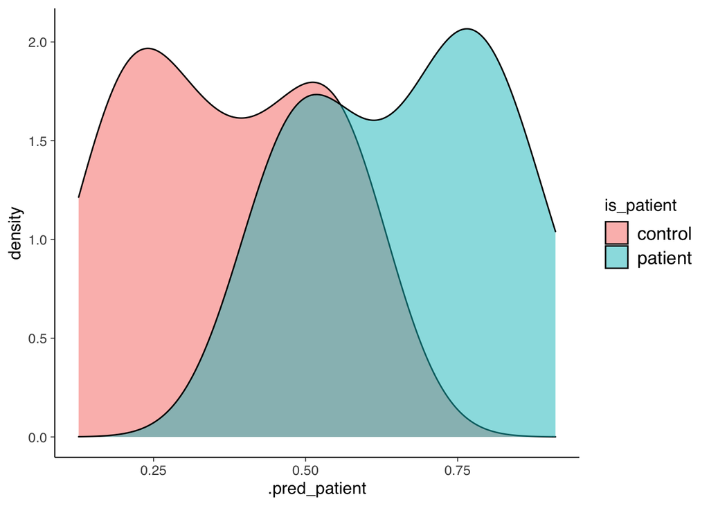

```r
test_predictions %>%
  ggplot() +
  geom_density(
    aes(x = .pred_patient, fill = is_patient),
    alpha = 0.5
  )
```

If you’re familiar with purrr, you could use purrr functions to extract the predictions column using pull(). The following code does almost the same thing as collect_predictions(). You could similarly have done this with the .metrics column.

```r
test_predictions <- rf_fit %>% pull(.predictions)
test_predictions
```

```
## [[1]]
## # A tibble: 25 × 6
##    .pred_control .pred_patient  .row .pred_class is_patient .config
##            <dbl>         <dbl> <int> <fct>       <fct>      <chr>
##  1         0.302         0.698     1 patient     patient    Preprocessor1_Model1
##  2         0.174         0.826     2 patient     patient    Preprocessor1_Model1
##  3         0.543         0.457     5 control     patient    Preprocessor1_Model1
##  4         0.198         0.802     7 patient     patient    Preprocessor1_Model1
##  5         0.218         0.782    12 patient     patient    Preprocessor1_Model1
##  6         0.505         0.495    13 control     patient    Preprocessor1_Model1
##  7         0.319         0.681    18 patient     patient    Preprocessor1_Model1
##  8         0.460         0.540    20 patient     patient    Preprocessor1_Model1
##  9         0.564         0.436    21 control     patient    Preprocessor1_Model1
## 10         0.240         0.760    27 patient     patient    Preprocessor1_Model1
## # … with 15 more rows
```

## Fitting and using your final model

The previous section evaluated the model trained on the training data using the testing data. But once you’ve determined your final model, you often want to train it on your full dataset and then use it to predict the response for new data.

If you want to use your model to predict the response for new observations, you need to use the fit() function on your workflow and the dataset that you want to fit the final model on (e.g. the complete training + testing dataset).

```r
final_model <- fit(rf_workflow, dat)
```

```r
final_model
```

```
## ══ Workflow [trained] ══════════════════════════════════════════════════════════════════════════
## Preprocessor: Recipe
## Model: rand_forest()
##
## ── Preprocessor ────────────────────────────────────────────────────────────────────────────────
## 2 Recipe Steps
##
## • step_normalize()
## • step_impute_knn()
##
## ── Model ───────────────────────────────────────────────────────────────────────────────────────
## Ranger result
##
## Call:
##  ranger::ranger(x = maybe_data_frame(x), y = y, mtry = min_cols(~3,      x), num.trees = ~500, importance = ~"impurity", num.threads = 1,      verbose = FALSE, seed = sample.int(10^5, 1), probability = TRUE)
##
## Type:                             Probability estimation
## Number of trees:                  500
## Sample size:                      62
## Number of independent variables:  4
## Mtry:                             3
## Target node size:                 10
## Variable importance mode:         impurity
## Splitrule:                        gini
## OOB prediction error (Brier s.):  0.1767648
```

## Variable importance

```r
ranger_obj <- extract_fit_parsnip(final_model)$fit
ranger_obj
```

```
## Ranger result
##
## Call:
##  ranger::ranger(x = maybe_data_frame(x), y = y, mtry = min_cols(~3,      x), num.trees = ~500, importance = ~"impurity", num.threads = 1,      verbose = FALSE, seed = sample.int(10^5, 1), probability = TRUE)
##
## Type:                             Probability estimation
## Number of trees:                  500
## Sample size:                      62
## Number of independent variables:  4
## Mtry:                             3
## Target node size:                 10
## Variable importance mode:         impurity
## Splitrule:                        gini
## OOB prediction error (Brier s.):  0.1767648
```

Then you can extract the variable importance from the ranger object itself (variable.importance is a specific object contained within ranger output - this will need to be adapted for the specific object type of other models).

```r
ranger_obj$variable.importance
```

```
##        alpha_food     alpha_neutral    pos_alpha_food pos_alpha_neutral
##          6.001988          2.914522         11.395728          5.007050
```